# Deforest–TidyTuesday Week15,2021

Twitter @Sky013088 | Email: sky013088@gmail.com

4/19/2021

## step 0: first tidyverse Project Data.

I am excited to start TidyTuesday project, and joined this online learning community. After looking at the overall dataset for forest loss, I found Brazil has the worse forest loss year over year, so I am curious about what causes this phenomenon. Below I answered the question: *what are the top 5 reasons for Brazil’s forest lost ?* I obtained the data according to the instruction here in < https://github.com/rfordatascience/tidytuesday/tree/master/data/2021/2021-04-06>.

## step 1: rank the Brazil_loss data

according the following steps. I would have summed up the total loss from 2001-2013 and rank value. However I decided to use the other method. In this method, I rank the loss consistently rank the top year over year as the top 5 reasons. I liste my steps here : * group the data by year * use mutate() to give each value a score * ungroup the dataset * regroup it by loss * use summarize() to obtain the median of each loss * use min_rank() to find out the top 5

```r
load(file="brazil_loss.Rdata")


brazilloss3 <- gather(brazil_loss ,key="loss",value="value",4:14)

top5 <- brazil_loss  %>%
  gather(key="loss",value="value",4:14) %>%
  group_by(year) %>%
  mutate(rank=min_rank(value)) %>%
  ungroup %>%
  group_by(loss) %>%
  summarise(score=median(rank)) %>%
  arrange(desc(score)) %>%
  top_n(5)

top5_data <- semi_join(brazilloss3,top5,by="loss")
```

## step 2, Including Plots

I can also embed plots using ggplot2 and ggdark

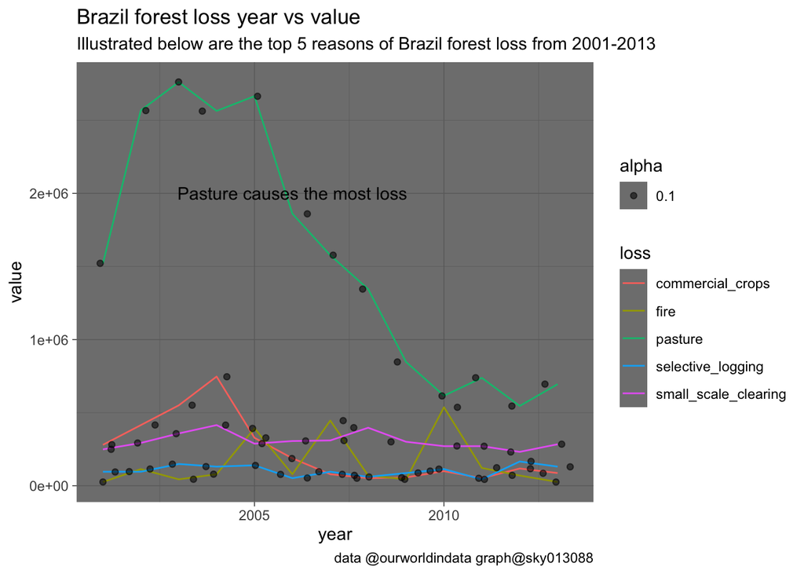

```r
top5_data %>%
ggplot(mapping=aes(x=year,y=value))+
  geom_line(mapping=aes(color=loss))+
  geom_point(aes(alpha=0.1),position="jitter") +

  labs( title="Brazil forest loss year vs value",
        subtitle="Illustrated below are the top 5 reasons of Brazil forest loss from 2001-2013",
        caption ="data @ourworldindata graph@sky013088"
  )+

  annotate("text",x=2006,y=2e+06,label="Pasture causes the most loss")+
  theme(legend.position="bottom")+
  theme_dark()
```